# Abundance Analysis - Top Taxa

### Non-CRS

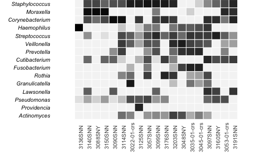

```r
heatmap.NonCRS <- amp_heatmap(ampvis.NonCRS,
                           tax_aggregate = "Genus",
                           tax_show = 15,
                           plot_values = FALSE,
                           plot_colorscale = "log10",
                           normalise = TRUE,
                           order_x_by = "cluster",
                           color_vector = c("whitesmoke", "black") #"#347A88"
                           ) +
  theme_minimal(base_size = 14) +
  theme(axis.text.x = element_text(angle=90),
        #axis.text.x = element_blank(),
        axis.text.y = element_text(face="italic", color = "black"),
        axis.ticks = element_blank(),
        legend.position = "",
        panel.grid = element_blank(),
        plot.margin = margin(0,0,0,0, unit = "cm"),
        ) +
  scale_x_discrete(expand = c(0,3)) +
  scale_y_discrete(expand = c(0,0)) #+
  #coord_fixed(ratio=1)


heatmap.NonCRS
```

```r
heatmap.NonCRS.df <- amp_heatmap(ampvis.NonCRS,
                           textmap = TRUE,
                           tax_show = 15,
                           tax_aggregate = "Genus",
                           plot_values = FALSE,
                           normalise = TRUE,
                           order_x_by = "cluster",
                           )
heatmap.NonCRS.df
```

|  | 3136SNN | 3140SNN | 3088SNY | 3150SNN | 3090SNN | 3114SNN | 3022-01-crs | 3125SNN | 3057SNN | 3099SNN | 3176SNN | 3203SNN | 3048SNY | 3035-01-crs | 3045-01-crs | 3097SNN | 3160SNY | 3053-01-crs | 3191SNN |
| --- | --- | --- | --- | --- | --- | --- | --- | --- | --- | --- | --- | --- | --- | --- | --- | --- | --- | --- | --- |
| Staphylococcus | 0.00 | 7.05 | 7.20 | 2.95 | 5.25 | 5.20 | 33.45 | 32.20 | 53.75 | 45.30 | 36.95 | 22.10 | 0.00 | 0.00 | 0.20 | 1.05 | 2.90 | 7.00 | 22.60 |
| Moraxella | 0.00 | 72.15 | 85.55 | 85.20 | 0.00 | 0.00 | 0.00 | 0.00 | 0.00 | 1.45 | 0.00 | 0.00 | 0.00 | 0.20 | 0.00 | 0.00 | 0.00 | 20.90 | 15.75 |
| Corynebacterium | 0.00 | 6.40 | 2.20 | 6.80 | 80.00 | 60.50 | 0.00 | 11.55 | 0.10 | 6.75 | 18.85 | 9.95 | 0.00 | 0.00 | 0.00 | 16.90 | 17.00 | 1.70 | 24.25 |
| Haemophilus | 99.85 | 0.00 | 0.00 | 0.00 | 0.05 | 0.25 | 0.00 | 0.20 | 1.40 | 1.55 | 0.00 | 1.70 | 4.45 | 3.45 | 5.05 | 12.25 | 0.00 | 0.00 | 0.10 |
| Streptococcus | 0.00 | 0.85 | 0.00 | 0.15 | 0.05 | 6.20 | 3.55 | 0.65 | 6.05 | 20.50 | 2.70 | 9.55 | 2.35 | 13.10 | 11.35 | 10.60 | 30.90 | 3.40 | 0.80 |
| Veillonella | 0.00 | 0.00 | 0.00 | 0.00 | 0.05 | 10.10 | 3.40 | 0.50 | 4.50 | 4.15 | 0.10 | 19.25 | 34.35 | 8.15 | 5.85 | 4.15 | 0.00 | 0.55 | 0.60 |
| Prevotella | 0.00 | 0.00 | 0.00 | 0.00 | 0.90 | 8.90 | 0.00 | 0.00 | 0.80 | 5.15 | 0.00 | 2.35 | 14.75 | 16.75 | 21.05 | 0.00 | 0.00 | 1.25 | 0.00 |
| Cutibacterium | 0.00 | 2.50 | 0.00 | 2.75 | 3.00 | 0.20 | 0.00 | 0.40 | 5.25 | 0.15 | 9.50 | 1.20 | 0.00 | 0.00 | 0.00 | 21.45 | 5.75 | 6.35 | 10.00 |
| Fusobacterium | 0.00 | 0.00 | 0.00 | 0.00 | 0.00 | 0.00 | 0.40 | 0.00 | 1.45 | 0.00 | 0.00 | 0.40 | 8.70 | 27.65 | 28.75 | 0.00 | 0.00 | 0.00 | 0.00 |
| Rothia | 0.00 | 0.00 | 0.00 | 0.00 | 0.00 | 1.15 | 2.35 | 0.00 | 9.30 | 0.00 | 23.95 | 11.95 | 0.00 | 0.50 | 0.60 | 6.50 | 0.00 | 0.00 | 0.10 |

[output cut: 5 more lines]

```r
#ggsave(heatmap.NonCRS,
#       filename = "../figures/taxaHeatPlotNonCRS.pdf",
#       device = "pdf",
#       height = 3.0,
#       width = 4.5)
```

```r
nonCRSheatLegend <- get_legend(heatmap.NonCRS + theme(legend.position = "bottom"))
```

```
Transformation introduced infinite values in discrete y-axis
```

```r
#ggsave(nonCRSheatLegend, filename = "../figures/nonCRSheatmapLegend.pdf",
#       height = 1, width = 3)
```

Make barplot from averages of these numbers

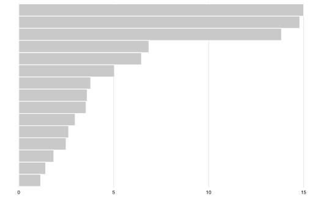

```r
heatmap.NonCRS.df.meanRA <- heatmap.NonCRS.df %>%
  rownames_to_column("Genus") %>%
  pivot_longer(-Genus, names_to = "Sample", values_to = "RA") %>%
  group_by(Genus) %>%
  dplyr::summarise(meanRA = mean(RA)) %>%
  dplyr::arrange(desc(meanRA))
# Make a barplot
meanRAbarNonCRS <- ggplot(heatmap.NonCRS.df.meanRA, aes(x = reorder(Genus,meanRA), y = meanRA)) +
  geom_col(fill = "lightgrey", color = "white", width = 1) +
  coord_flip() +
  theme_minimal(base_size = 10) +
  theme(axis.text.y = element_blank(),
        axis.ticks.y = element_blank(),
        axis.title.y = element_blank(),
        axis.title.x = element_blank(),
        axis.text.x = element_text(color = "black"),
        panel.grid.major.y = element_blank(),
        panel.grid.minor = element_blank())
meanRAbarNonCRS
```

```r
#ggsave(meanRAbarNonCRS, filename = "../figures/meanRAbarplotNonCRS.pdf",
#       device ="pdf",
#       height = 3.1,
#       width = 0.8)
```

```r
#saveRDS(heatmap.NonCRS.df, "../data/heatmap_NonCRS_df.rds")
```

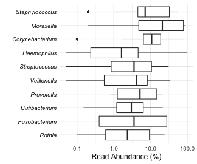

```r
boxplot.NonCRS.grouped <- amp_boxplot(ampvis.NonCRS,
                           tax_aggregate = "Genus",
                           sort_by = "mean",
                           tax_show = 10,
                           plot_log = T,
                           ) +
  #scale_y_log10() +
  theme_minimal(base_size = 12) +
  theme(axis.text.y = element_text(face = "italic", color = "black"),
        axis.ticks = element_blank(),
        legend.position = ""
  )
boxplot.NonCRS.grouped
```

### Whole dataset: CRS/Non-CRS

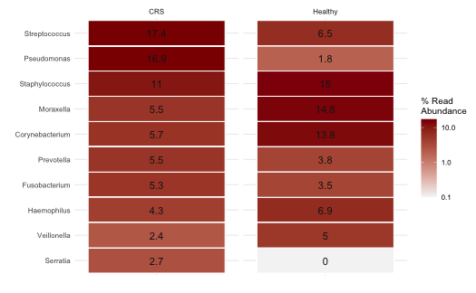

```r
heatmap.obj <- amp_heatmap(ampvis.obj,
                           group_by = "DIAG_CRS",
                           facet_by = "DIAG_CRS",
                           tax_aggregate = "Genus",
                           plot_values = TRUE,
                           #tax_add = "Phylum",
                           #tax_show = 15,
                           plot_colorscale = "log10",
                           normalise = TRUE,
                           #order_x_by = "hclust",
                           color_vector = c("whitesmoke", "darkred"),
                           ) +
  theme_minimal(base_size = 10) +
  theme(axis.text.x = element_blank(),
        axis.ticks = element_blank(),
        legend.position = "right")
heatmap.obj
```

# Table of anaerobe mean relative abundances

```r
Anaerobes <- c("Fusobacterium", "Prevotella", "Parvimonas", "Peptostreptococcus", "Cutibacterium", "Leptotrichia", "Anaerococcus","Peptoniphilus","Veillonella","Akkermansia","Finegoldia","Clostridium","Bacteroides","Porphyromonas","Actinomyces","Streptococcus","Selenomonas","Tannerella", "Dialister","Capnocytophaga", "Gemella","Eikenella", "Solobacterium", "Campylobacter","Atopobium", "Oribacterium","Treponema","Rothia","Granulicatella")
```

## Agglomerate CRS and Non-CRS datasets by the “TaxName” level.

```r
CRS.taxname <- tax_glom(CRS, "TaxName")
CRS.taxname
```

```
phyloseq-class experiment-level object
otu_table()   OTU Table:         [ 204 taxa and 61 samples ]
sample_data() Sample Data:       [ 61 samples by 183 sample variables ]
tax_table()   Taxonomy Table:    [ 204 taxa by 10 taxonomic ranks ]
```

```r
nonCRS.taxname <- tax_glom(nonCRS, "TaxName")
nonCRS.taxname
```

```
phyloseq-class experiment-level object
otu_table()   OTU Table:         [ 155 taxa and 19 samples ]
sample_data() Sample Data:       [ 19 samples by 183 sample variables ]
tax_table()   Taxonomy Table:    [ 155 taxa by 10 taxonomic ranks ]
```

## Calculate relative abundances for each taxname

```r
CRS.taxname.prop <- transform_sample_counts(CRS.taxname, function(x) x/sum(x) * 100)
nonCRS.taxname.prop <- transform_sample_counts(nonCRS.taxname, function(x) x/sum(x) * 100)
```

## Summarize relative abundances by the mean

Get a table of average relative abundances for each taxname, take the average across the samples, including zeros in the calculation (So data matches up with the ampvis heatmaps, which calculate average relative abundances including zeros)

```r
CRS.taxname.prop.melt <- psmelt(CRS.taxname.prop) %>%
  #filter(Abundance > 0) #%>%
  group_by(OTU, Phylum, Class, Order, Family, Genus, Species, TaxName) %>%
  dplyr::summarize(avgRelAbun = mean(Abundance)) %>%
  ungroup() %>%
  select(TaxName, avgRelAbun)
dim(CRS.taxname.prop.melt)
```

```
[1] 204   2
```

```r
nonCRS.taxname.prop.melt <- psmelt(nonCRS.taxname.prop) %>%
  #filter(Abundance > 0) %>%
  group_by(OTU, Phylum, Class, Order, Family, Genus, Species, TaxName) %>%
  dplyr::summarize(avgRelAbun = mean(Abundance)) %>%
  ungroup() %>%
  select(TaxName, avgRelAbun)
dim(nonCRS.taxname.prop.melt)
```

```
[1] 155   2
```

## Prevalence, feature counts, and percent of total sequences for each TaxName

Calculated from the original, non-transformed dataset. Bind to dataframe of mean relative abundances.

### CRS

```r
# Compute prevalence of each feature, store as data.frame
prevdf.taxname.CRS = apply(X = otu_table(CRS.taxname),
               MARGIN = ifelse(taxa_are_rows(CRS.taxname), yes = 1, no = 2),
               FUN = function(x){sum(x > 0)})
# Add taxonomy and total read counts to this data.frame
prevdf.taxname.CRS = data.frame(Prevalence = prevdf.taxname.CRS,
                    Abundance = taxa_sums(CRS.taxname),
                    phyloseq::tax_table(CRS.taxname)@.Data) %>%
  mutate(PercentAbundance = round(Abundance/sum(Abundance) * 100, 4)) %>%
  rownames_to_column("ASV") %>%
  left_join(CRS.taxname.prop.melt, by = "TaxName") %>%
  column_to_rownames("ASV") %>%
  select(Prevalence, Abundance, PercentAbundance, avgRelAbun, TaxName, everything(), -DB) %>%
  mutate(DIAG_CRS = "CRS")
dim(prevdf.taxname.CRS)
```

```
[1] 204  14
```

### Non-CRS

```r
# Compute prevalence of each feature, store as data.frame
prevdf.taxname.nonCRS = apply(X = otu_table(nonCRS.taxname),
               MARGIN = ifelse(taxa_are_rows(nonCRS.taxname), yes = 1, no = 2),
               FUN = function(x){sum(x > 0)})
# Add taxonomy and total read counts to this data.frame
prevdf.taxname.nonCRS = data.frame(Prevalence = prevdf.taxname.nonCRS,
                    Abundance = taxa_sums(nonCRS.taxname),
                    phyloseq::tax_table(nonCRS.taxname)@.Data) %>%
  mutate(PercentAbundance = round(Abundance/sum(Abundance) * 100, 4)) %>%
  rownames_to_column("ASV") %>%
  left_join(nonCRS.taxname.prop.melt, by = "TaxName") %>%
  column_to_rownames("ASV") %>%
  select(Prevalence, Abundance, PercentAbundance, avgRelAbun, TaxName, everything(), -DB) %>%
  mutate(DIAG_CRS = "NonCRS")
```

## Filter to include just Anaerobes

```r
prevdf.taxname.CRS.anaerobes <- filter(prevdf.taxname.CRS, Genus %in% Anaerobes)
```

```r
prevdf.taxname.nonCRS.anaerobes <- filter(prevdf.taxname.nonCRS, Genus %in% Anaerobes)
```

## Bind the two tables together

```r
prevdf.taxname.anaerobes <- bind_rows(prevdf.taxname.CRS.anaerobes, prevdf.taxname.nonCRS.anaerobes) %>%
  pivot_wider(id_cols = TaxName:Genus_Species2, names_from = DIAG_CRS, values_from = c("Prevalence","Abundance","PercentAbundance", "avgRelAbun")) %>%
  select(Kingdom, Phylum, Class, Order, Family, Genus, Species, TaxName,
         Prevalence_CRS, Prevalence_NonCRS, Abundance_CRS, Abundance_NonCRS,
         PercentAbundance_CRS, PercentAbundance_NonCRS, avgRelAbun_CRS, avgRelAbun_NonCRS) %>%
  arrange(Genus, TaxName)
```

## Export as a .CSV

```r
write_csv(prevdf.taxname.anaerobes, "../data/anaerobePrevAbun.csv")
```

# Relative Abundance Boxplots

## Agglomerate data to the Genus level.

```r
anaerobes.prop <- data %>%
  tax_glom("Genus") %>%
  transform_sample_counts(function(x) x/sum(x) * 100) %>%
  subset_taxa(Genus %in% Anaerobes) %>%
  psmelt()
```

## Boxplots

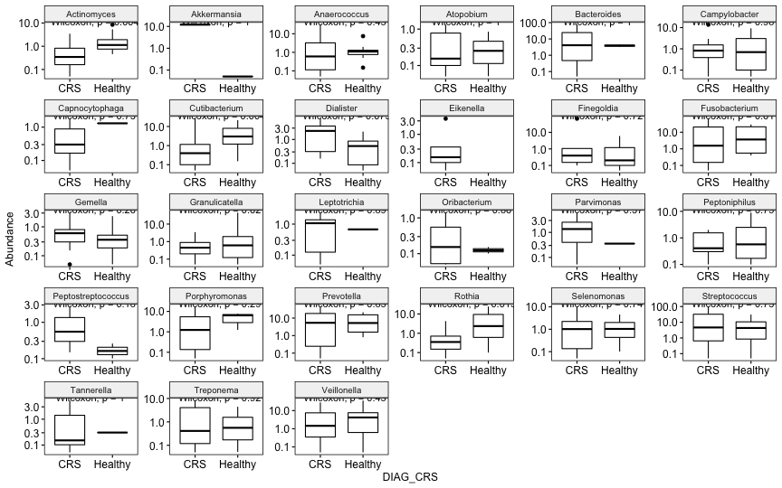

```r
p <- ggboxplot(anaerobes.prop,
              x = "DIAG_CRS", y = "Abundance",
              #add = "jitter",
              facet.by = "Genus",
              scales = "free"
              ) +
  stat_compare_means(aes(group = DIAG_CRS), method = "wilcox.test") +
  scale_y_log10()
p
```

```r
plot_abundance = function(physeq,title = "",
                 Facet = "Genus", Color = "DIAG_CRS"){
  # Arbitrary subset, based on Phylum, for plotting
  p1f = subset_taxa(physeq, Phylum %in% c("Bacteroidetes","Fusobacteria"))
  mphyseq = psmelt(p1f)
  mphyseq <- subset(mphyseq, Abundance > 0)
  ggplot(data = mphyseq, mapping = aes_string(x = "DIAG_CRS",y = "Abundance",
                                 color = Color, fill = Color)) +
    geom_boxplot(fill = NA) +
    geom_point(size = 1, alpha = 0.3,
                position = position_jitter(width = 0.3)) +
    theme_minimal() +
    facet_wrap(facets = Facet, scales = "free") +
    scale_y_log10() +
    theme(legend.position="none",
          axis.text.x = element_text(angle = 90))
}
```

transform data

```r
CRSprop <- transform_sample_counts(CRS, function(x) x/sum(x) * 100)
NonCRSprop <- transform_sample_counts(nonCRS, function(x) x/sum(x) * 100)
```

```r
dataProp <- transform_sample_counts(data, function(x) x/sum(x)*100)
dataLog <- transform_sample_counts(data, function(x) log(1 + x))
```

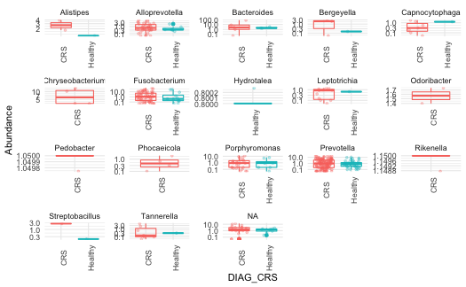

```r
TopTaxPropPlotCRS <- plot_abundance(dataProp, Facet = "Genus", Color = "DIAG_CRS")
TopTaxPropPlotCRS
```

## Agglomerate data to the Phylum level.

```r
Phylum.prop <- data %>%
  tax_glom("Phylum") %>%
  transform_sample_counts(function(x) x/sum(x) * 100) %>%
  psmelt() %>%
  filter(Abundance > 0)
```

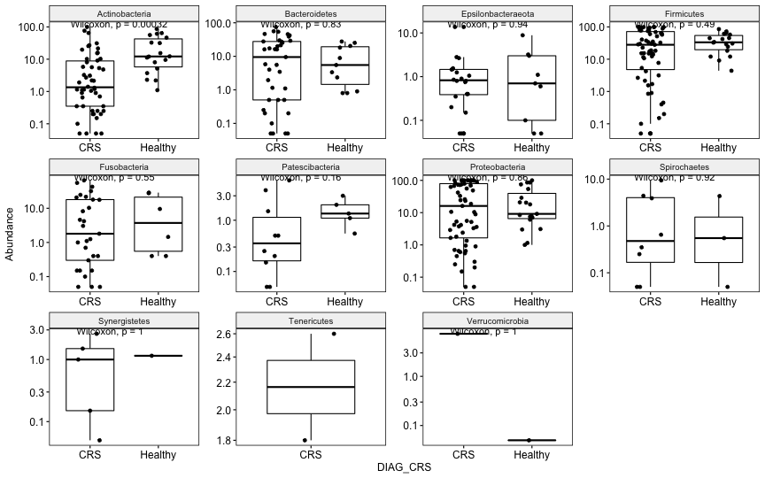

```r
p <- ggboxplot(Phylum.prop,
              x = "DIAG_CRS", y = "Abundance",
              add = "jitter",
              facet.by = "Phylum",
              scales = "free"
              ) +
  stat_compare_means(method = "wilcox.test") +
  scale_y_log10()
p
```

# Stacked bargraphs

## Agglomerate data to the Phylum level.

```r
dataPhylumPropMelt <- data %>%
  tax_glom("Phylum") %>%
  transform_sample_counts(function(x) x/sum(x) * 100) %>%
  psmelt()
# Make anything with an abundance less than 1% "Other"
dataPhylumPropMelt$Phylum <- as.character(dataPhylumPropMelt$Phylum)
dataPhylumPropMelt <- mutate(dataPhylumPropMelt, PhylumOther = ifelse(Abundance < 1, "Other < 1%", Phylum))

bugcolors <- read_csv("../CRS_Taxa_Colors.csv")
dataPhylumPropMelt <- left_join(dataPhylumPropMelt, bugcolors, by = c("PhylumOther" = "Taxon")) %>%
  select(SAMPLE_NAME, subject_id, DIAG_CRS, SINUS_FACTORS_NUMFESS, SINUS_FACTORS_PRIORFESS, contains("ABX"), Phylum, PhylumOther, Abundance, Color)
#Separate CRS and non CRS datasets, arrange, and get sample names for plotting
dataPhylumPropMeltCRS <- dataPhylumPropMelt %>%
  filter(DIAG_CRS == "CRS") %>%
  dplyr::arrange(DIAG_CRS, PhylumOther, desc(Abundance))

dataPhylumPropMeltNonCRS <- dataPhylumPropMelt %>%
  filter(DIAG_CRS == "Healthy") %>%
  dplyr::arrange(DIAG_CRS, PhylumOther, desc(Abundance))


orderXCRS <- unique(dataPhylumPropMeltCRS$SAMPLE_NAME)
labelsXCRS <- unique(dataPhylumPropMeltCRS$subject_id)
orderXNonCRS <- unique(dataPhylumPropMeltNonCRS$SAMPLE_NAME)
labelsXNonCRS <- unique(dataPhylumPropMeltNonCRS$subject_id)
```

```r
colorTax <- unique(dataPhylumPropMeltCRS$PhylumOther)
colorHex <- unique(dataPhylumPropMeltCRS$Color)

#barplot.prop <- ggplot(data=dataPhylumPropMelt, aes(x = SAMPLE_NAME, y = Abundance, fill = PhylumOther)) +
#  #facet_grid(~DIAG_CRS, scales = "free", space = "free") +
#  geom_bar(aes(), stat="identity", position="stack") +
#  scale_x_discrete(limits = orderXCRS,
#                   labels = labelsXCRS) +
#  theme_minimal(base_size = 14) +
#  theme(axis.title.x = element_blank(),
#        axis.text.x = element_blank(),
#        axis.text.y = element_text(color = "black"),
#        plot.margin = margin(0,0,0,0, "cm"),
#        panel.grid = element_blank()) +
#  scale_fill_manual(breaks = colorTax, values = colorHex) #+
#  #ggtitle("CRS Samples")
#barplot.prop
```

```r
clinicalData <- data.frame(sample_data(data))
```

```r
sinusFactorsCRS <- clinicalData %>%
  select(SAMPLE_NAME, DIAG_CRS, contains("SINUS_FACTORS"), LABS_COAG_NEG_STAPH, LABS_S_AUREUS, LABS_P_AERUGINOSA, LABS_P_AERUGINOSA_MUCOID, LABS_STREP_PNEUMO ) %>%
  select(-contains("OTHER")) %>%
  filter(!is.na(SINUS_FACTORS_COMPLETE)) %>%
  select(-SINUS_FACTORS_COMPLETE, -SINUS_FACTORS_POLYPOIDCHANGE, -SINUS_FACTORS_NUMFESS, -SINUS_FACTORS_SUBSEQFESS) %>%
  mutate(LABS_S_AUREUS_BIN = ifelse(LABS_S_AUREUS == "Positive",1,0),
         LABS_COAG_NEG_STAPH_BIN = ifelse(LABS_COAG_NEG_STAPH == "Positive",1,0),
         LABS_STREP_PNEUMO_BIN = ifelse(LABS_STREP_PNEUMO == "Positive",1,0),
         LABS_P_AERUGINOSA_BIN = ifelse(LABS_P_AERUGINOSA == "Positive",1,0),
         LABS_P_AERUGINOSA_MUCOID_BIN = ifelse(LABS_P_AERUGINOSA_MUCOID == "Positive",1,0)) %>%
  dplyr::rename(Smoker = SINUS_FACTORS_SMOKER,
                Polyps = SINUS_FACTORS_POLYPS,
                GERD = SINUS_FACTORS_GERD,
                Asthma = SINUS_FACTORS_ASTHMA,
                Allergies = SINUS_FACTORS_ALLERGIES,
                'Prior FESS' = SINUS_FACTORS_PRIORFESS,
                'Culture: S. aureus' = LABS_S_AUREUS_BIN,
                'Culture: Coag.Neg.Staph' = LABS_COAG_NEG_STAPH_BIN,
                'Culture: S. pneumoniae' = LABS_STREP_PNEUMO_BIN,
                'Culture: P. aeruginosa' = LABS_P_AERUGINOSA_BIN,
                'Culture: P. aeruginosa (mucoid)' = LABS_P_AERUGINOSA_MUCOID_BIN) %>%
  pivot_longer(cols = c("Smoker","Polyps", "GERD", "Asthma", "Allergies", "Prior FESS",
                        'Culture: S. aureus','Culture: Coag.Neg.Staph','Culture: S. pneumoniae',
                        'Culture: P. aeruginosa','Culture: P. aeruginosa (mucoid)'),
               names_to = "FACTOR", values_to = "boo") %>%
  mutate(BOOL = ifelse(boo == 1, TRUE,FALSE)) %>%
  filter(DIAG_CRS == "CRS")
sinusFactorsCRS
```

| SAMPLE_NAME | DIAG_CRS | LABS_COAG_NEG_STAPH | LABS_S_AUREUS | LABS_P_AERUGINOSA | LABS_P_AERUGINOSA_MUCOID | LABS_STREP_PNEUMO | FACTOR | boo | BOOL |
| --- | --- | --- | --- | --- | --- | --- | --- | --- | --- |
| 3002-01-crs | CRS | Negative | Negative | Negative | Negative | Negative | Smoker | 0 | FALSE |
| 3002-01-crs | CRS | Negative | Negative | Negative | Negative | Negative | Polyps | 0 | FALSE |
| 3002-01-crs | CRS | Negative | Negative | Negative | Negative | Negative | GERD | 0 | FALSE |
| 3002-01-crs | CRS | Negative | Negative | Negative | Negative | Negative | Asthma | 1 | TRUE |
| 3002-01-crs | CRS | Negative | Negative | Negative | Negative | Negative | Allergies | 1 | TRUE |
| 3002-01-crs | CRS | Negative | Negative | Negative | Negative | Negative | Prior FESS | 1 | TRUE |
| 3002-01-crs | CRS | Negative | Negative | Negative | Negative | Negative | Culture: S. aureus | 0 | FALSE |
| 3002-01-crs | CRS | Negative | Negative | Negative | Negative | Negative | Culture: Coag.Neg.Staph | 0 | FALSE |
| 3002-01-crs | CRS | Negative | Negative | Negative | Negative | Negative | Culture: S. pneumoniae | 0 | FALSE |
| 3002-01-crs | CRS | Negative | Negative | Negative | Negative | Negative | Culture: P. aeruginosa | 0 | FALSE |

[output cut: 661 more lines]

Just filter to PriorFESS

```r
CRSpriorFESS <- filter(sinusFactorsCRS, FACTOR == "Prior FESS")
CRSculture <- filter(sinusFactorsCRS, FACTOR %in% c('Culture: S. aureus','Culture: Coag.Neg.Staph','Culture: S. pneumoniae',
                        'Culture: P. aeruginosa','Culture: P. aeruginosa (mucoid)'))
```

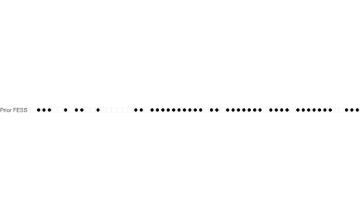

```r
CRScolorbar <- ggplot(CRSpriorFESS, aes(x = SAMPLE_NAME, y = FACTOR)) +
  geom_tile(colour = "whitesmoke",size=.5, aes(fill = BOOL)) +
  geom_point(aes(color = BOOL)) + # Make the squares dots instead
  scale_x_discrete(breaks = orderXCRS,
                   limits = orderXCRS,
                   expand = c(0,0)) + #Make the boxes square
  scale_y_discrete(expand = c(0,0)) + #Make the boxes square
  coord_fixed(ratio=1) +  #Make the boxes square
  #scale_fill_manual(values = c("white", "black")) +
  scale_fill_manual(values = c("white", "white")) + # Make the squares dots instead
  scale_color_manual(values = c("white", "black")) + # Make the squares dots instead
  theme_minimal(base_size = 10) +
  theme(legend.position = "",
        axis.text.x = element_blank(),
        #axis.text.x = element_text(angle=90),
        axis.ticks = element_blank(),
        axis.title = element_blank(),
        plot.margin = margin(0,0,0,0, "cm"))
CRScolorbar
```

Now Get the number of prior FESS

```r
CRSNumFESSS <- clinicalData %>%
  data.frame() %>%
  select(SAMPLE_NAME, subject_id, DIAG_CRS, SINUS_FACTORS_NUMFESS) %>%
  dplyr::rename("# Prior FESS" = SINUS_FACTORS_NUMFESS) %>%
  pivot_longer(cols = "# Prior FESS", names_to = "FACTOR", values_to = "VALUE") %>%
  replace_with_na(replace = list(VALUE = 0)) %>%
  #filter(FACTOR %in% snot20PlotKeep) %>%
  filter(DIAG_CRS == "CRS")
```